# Peer Assessment II

# 1 Background

As a statistical consultant working for a real estate investment firm, your task is to develop a model to predict the selling price of a given home in Ames, Iowa. Your employer hopes to use this information to help assess whether the asking price of a house is higher or lower than the true value of the house. If the home is undervalued, it may be a good investment for the firm.

# 2 Training Data and relevant packages

In order to better assess the quality of the model you will produce, the data have been randomly divided into three separate pieces: a training data set, a testing data set, and a validation data set. For now we will load the training data set, the others will be loaded and used later.

```r
load("ames_train.Rdata")
```

Use the code block below to load any necessary packages

```r
library(statsr)
library(dplyr)
library(BAS)
library(MASS)
library(ggplot2)
```

## 2.1 Part 1 - Exploratory Data Analysis (EDA)

When you first get your data, it’s very tempting to immediately begin fitting models and assessing how they perform. However, before you begin modeling, it’s absolutely essential to explore the structure of the data and the relationships between the variables in the data set.

Do a detailed EDA of the ames_train data set, to learn about the structure of the data and the relationships between the variables in the data set (refer to Introduction to Probability and Data, Week 2, for a reminder about EDA if needed). Your EDA should involve creating and reviewing many plots/graphs and considering the patterns and relationships you see.

After you have explored completely, submit the three graphs/plots that you found most informative during your EDA process, and briefly explain what you learned from each (why you found each informative).

### 2.1.1 Prices in Different Neighborhood

The mantra in real estate is “Location, Location, Location!” But how much prices could vary among neighborhoods?

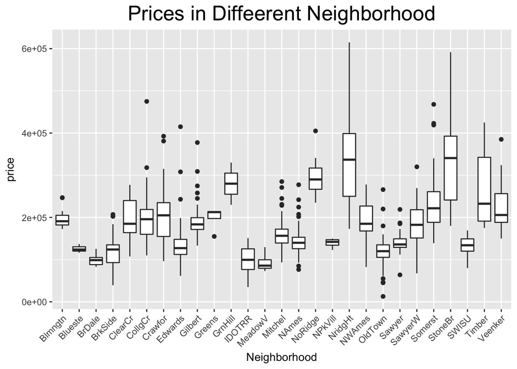

```r
ggplot(data = ames_train, aes(x = Neighborhood, y = price)) +
    geom_boxplot() +
    ggtitle("Prices in Diffeerent Neighborhood") +
    theme(plot.title = element_text(size = 20, hjust = 0.5),
          axis.text.x = element_text(angle = 45, hjust = 1))
```

From the boxplot above, we can see the properties in NridgHt and StoneBr tend to have highest prices with large vairiance, Meanwhile, those in BrDale and MeadowV are always much cheaper.

### 2.1.2 The Area of the Property and Its Price

Typically, we think larger house will have higher price. Now we have enough data points to examine the assumption.

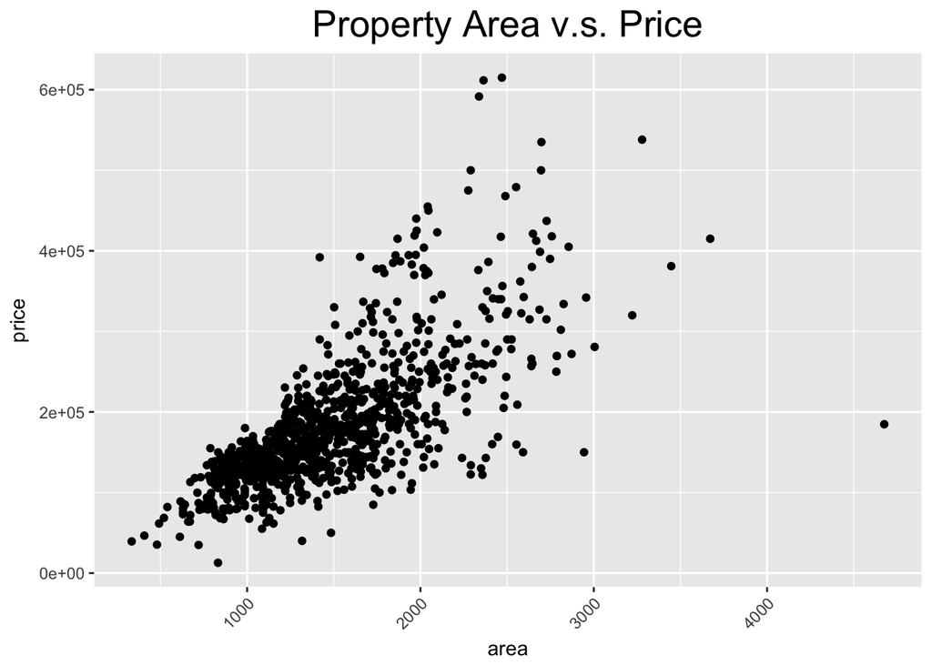

```r
ggplot(data = ames_train, aes(x = area, y = price)) +
    geom_point() +
    ggtitle("Property Area v.s. Price") +
    theme(plot.title = element_text(size = 20, hjust = 0.5),
          axis.text.x = element_text(angle = 45, hjust = 1))
```

From this plot, we can see there is a general positicve trend between area and price. Meanwhile, when the house is very large, the variance of the house price also grows greatly. There are also some abvious outliers, with large area but very low price. Besides, the house has highest price is not the house has largest area.

### 2.1.3 Property Age v.s. Price

Is older property more expensive or the opposite? We have pros for both arguments: One the one hand, new property has better maintenaince condition, thus should be more expensive; On the other hand, older property could have higher historical value and tends to be located in better geographical areas, contributing to its price. Let’s make a scatter plot to examine the arguments.

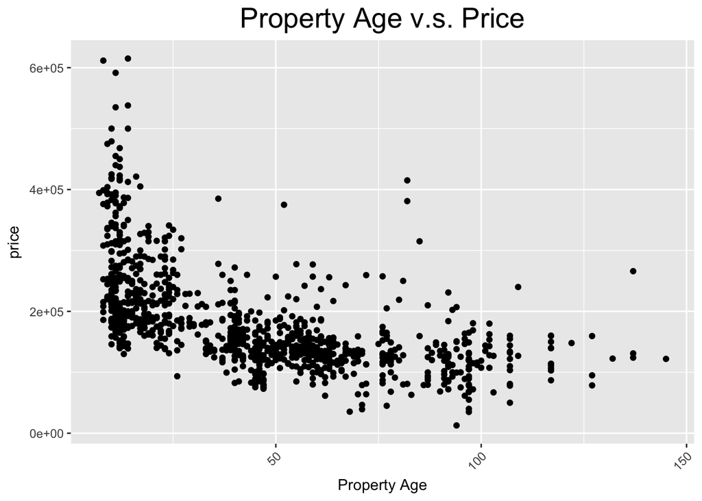

```r
ggplot(data = ames_train, aes(x = 2017-Year.Built, y = price)) +
    geom_point() +
    ggtitle("Property Age v.s. Price") +
    theme(plot.title = element_text(size = 20, hjust = 0.5),
          axis.text.x = element_text(angle = 45, hjust = 1)) +
    xlab("Property Age")
```

Overall, the older the property, the lower the price. Those properties that have highest price are those built recently new. There aren’t much difference of prices among the properties with age larger than 50 years. However, it’s worth to notice that there are fewer houses with higher age.

## 2.2 Part 2 - Development and assessment of an initial model, following a semi-guided process of analysis

### 2.2.1 Section 2.1 An Initial Model

In building a model, it is often useful to start by creating a simple, intuitive initial model based on the results of the exploratory data analysis. (Note: The goal at this stage is **not** to identify the “best” possible model but rather to choose a reasonable and understandable starting point. Later you will expand and revise this model to create your final model.

Based on your EDA, select *at most* 10 predictor variables from “ames_train” and create a linear model for `price` (or a transformed version of price) using those variables. Provide the *R code* and the *summary output table* for your model, a *brief justification* for the variables you have chosen, and a *brief discussion* of the model results in context (focused on the variables that appear to be important predictors and how they relate to sales price).

To start with, I built the prediction model with variables area, MS.Zoning, Neighborhood, Condition.1, Bldg.Type, Overall.Qual, Year.Built, Bsmt.Qual, Full.Bath. I selected these variables because they all seem have a strong relationship with the price.

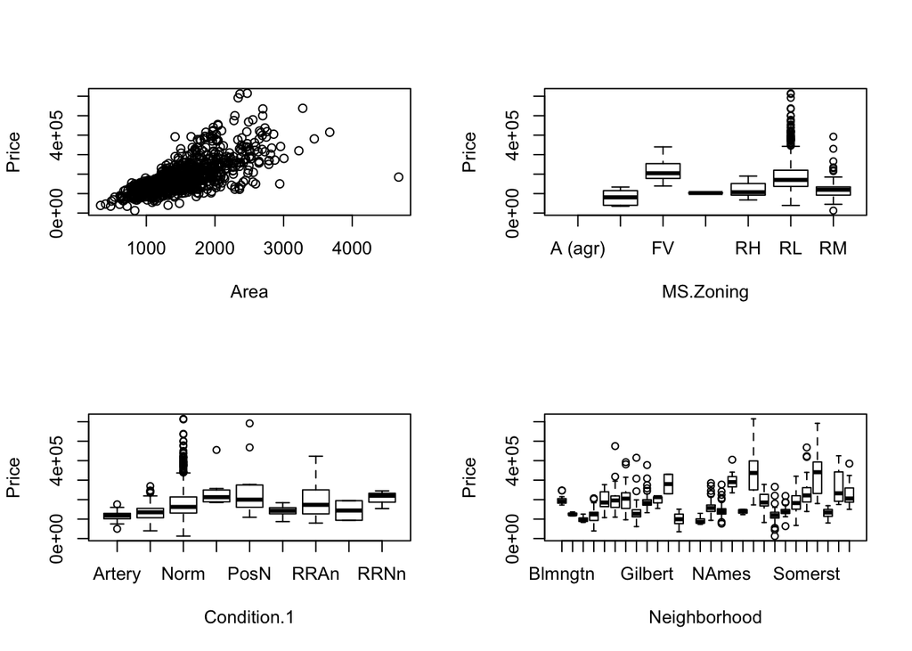

```r
par(mfrow = c(2,2))
plot(ames_train$area, ames_train$price,
     xlab = "Area", ylab = "Price")
boxplot(price ~ MS.Zoning, data = ames_train,
        xlab = "MS.Zoning", ylab = "Price")
boxplot(price ~ Condition.1, data = ames_train,
        xlab = "Condition.1", ylab = "Price")
boxplot(price ~ Neighborhood, data = ames_train,
        xlab = "Neighborhood", ylab = "Price")
```

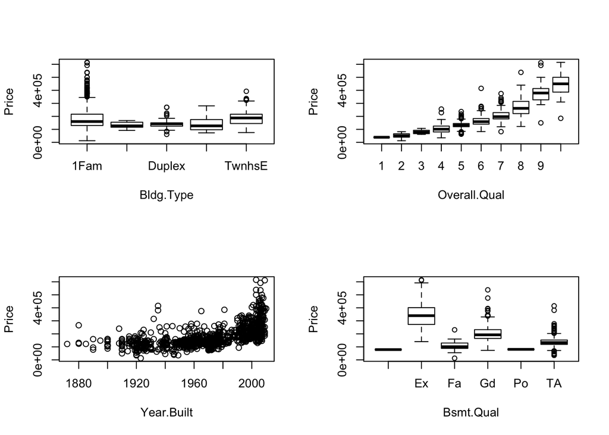

```r
boxplot(price ~ Bldg.Type, data = ames_train,
        xlab = "Bldg.Type", ylab = "Price")
boxplot(price ~ Overall.Qual, data = ames_train,
        xlab = "Overall.Qual", ylab = "Price")
plot(ames_train$Year.Built, ames_train$price,
     xlab = "Year.Built", ylab = "Price")
boxplot(price ~ Bsmt.Qual, data = ames_train,
        xlab = "Bsmt.Qual", ylab = "Price")
```

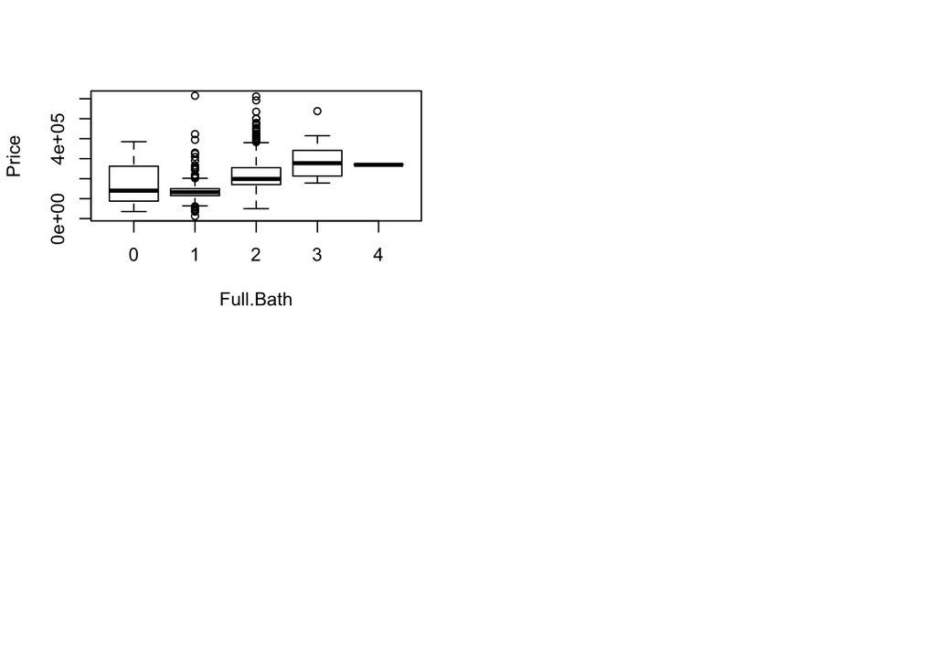

```r
boxplot(price ~ Full.Bath, data = ames_train,
        xlab = "Full.Bath", ylab = "Price")
```

Besides, since the distribution of price is highly right-skewed, I used **log(price)** as the response variable, instead of **price**.

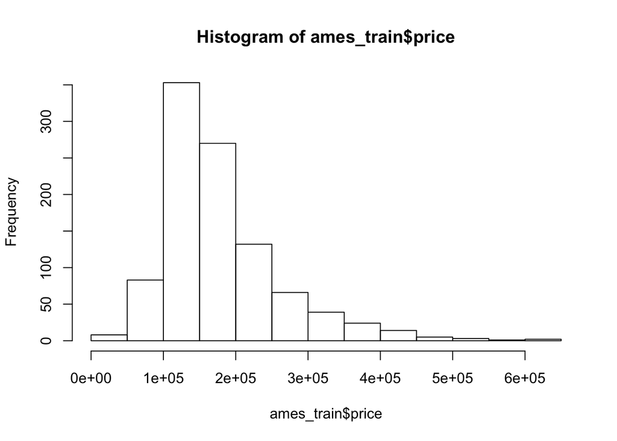

```r
hist(ames_train$price)
```

The regression model and summary:

```r
ames_train_valid = na.omit(ames_train[,c("price", "area", "MS.Zoning", "Neighborhood", "Condition.1", "Bldg.Type", "Overall.Qual", "Year.Built", "Bsmt.Qual", "Full.Bath")])
m_all = lm(log(price) ~ area +  MS.Zoning + Neighborhood + Condition.1 + Bldg.Type + Overall.Qual + Year.Built + Bsmt.Qual + Full.Bath, data = ames_train_valid)
summary(m_all)
```

```
##
## Call:
## lm(formula = log(price) ~ area + MS.Zoning + Neighborhood + Condition.1 +
##     Bldg.Type + Overall.Qual + Year.Built + Bsmt.Qual + Full.Bath,
##     data = ames_train_valid)
##
## Residuals:
##      Min       1Q   Median       3Q      Max
## -1.69335 -0.07262  0.00760  0.08566  0.56015
##
## Coefficients:
##                       Estimate Std. Error t value Pr(>|t|)
## (Intercept)          3.783e+00  9.553e-01   3.960 8.07e-05 ***
## area                 2.923e-04  1.729e-05  16.908  < 2e-16 ***
## MS.ZoningFV          2.958e-01  8.382e-02   3.529 0.000438 ***
## MS.ZoningI (all)     2.326e-01  1.711e-01   1.359 0.174417
## MS.ZoningRH          3.913e-01  9.696e-02   4.036 5.90e-05 ***
## MS.ZoningRL          4.280e-01  7.038e-02   6.082 1.74e-09 ***
## MS.ZoningRM          3.385e-01  6.443e-02   5.254 1.85e-07 ***
## NeighborhoodBlueste -1.099e-02  1.113e-01  -0.099 0.921420
## NeighborhoodBrDale  -1.360e-01  8.404e-02  -1.619 0.105852
## NeighborhoodBrkSide  4.549e-02  7.093e-02   0.641 0.521461
## NeighborhoodClearCr  1.168e-01  7.082e-02   1.649 0.099465 .
## NeighborhoodCollgCr -2.899e-02  5.505e-02  -0.527 0.598606
## NeighborhoodCrawfor  1.423e-01  6.388e-02   2.228 0.026129 *
## NeighborhoodEdwards -7.404e-02  5.906e-02  -1.254 0.210285
## NeighborhoodGilbert -7.803e-02  5.720e-02  -1.364 0.172833
## NeighborhoodGreens   1.145e-01  9.597e-02   1.194 0.232960
## NeighborhoodGrnHill  6.207e-01  1.698e-01   3.656 0.000271 ***
## NeighborhoodIDOTRR  -5.894e-02  7.732e-02  -0.762 0.446056
## NeighborhoodMeadowV -1.488e-01  7.321e-02  -2.033 0.042332 *
## NeighborhoodMitchel  1.494e-02  5.864e-02   0.255 0.798915
## NeighborhoodNAmes    1.062e-02  5.792e-02   0.183 0.854544
## NeighborhoodNoRidge  3.721e-02  6.092e-02   0.611 0.541474
## NeighborhoodNPkVill -2.716e-02  9.785e-02  -0.278 0.781419
## NeighborhoodNridgHt  1.149e-01  5.552e-02   2.070 0.038720 *
## NeighborhoodNWAmes  -3.709e-02  5.912e-02  -0.627 0.530512
## NeighborhoodOldTown -3.826e-03  7.239e-02  -0.053 0.957861
## NeighborhoodSawyer   2.058e-02  6.004e-02   0.343 0.731851
## NeighborhoodSawyerW -8.874e-02  5.760e-02  -1.541 0.123733
```

[output cut: 16 more lines]

```
## Bldg.TypeTwnhsE     -7.739e-02  2.547e-02  -3.039 0.002440 **
## Overall.Qual         9.215e-02  7.054e-03  13.062  < 2e-16 ***
## Year.Built           3.329e-03  4.684e-04   7.107 2.37e-12 ***
## Bsmt.QualEx          3.200e-01  1.668e-01   1.919 0.055328 .
## Bsmt.QualFa          1.201e-01  1.672e-01   0.719 0.472628
## Bsmt.QualGd          2.239e-01  1.650e-01   1.357 0.175001
## Bsmt.QualPo          5.418e-01  2.358e-01   2.298 0.021806 *
## Bsmt.QualTA          1.900e-01  1.641e-01   1.158 0.247053
## Full.Bath           -9.417e-03  1.590e-02  -0.592 0.553796
## ---
## Signif. codes:  0 '***' 0.001 '**' 0.01 '*' 0.05 '.' 0.1 ' ' 1
##
## Residual standard error: 0.1599 on 926 degrees of freedom
## Multiple R-squared:  0.8581, Adjusted R-squared:  0.8502
## F-statistic: 107.7 on 52 and 926 DF,  p-value: < 2.2e-16
```

From the summary part, we can see the current adjusted R-squared is 0.8502, indicating great fitting. However, many of the variables appear insignificant.

### 2.2.2 Section 2.2 Model Selection

Now either using `BAS` another stepwise selection procedure choose the “best” model you can, using your initial model as your starting point. Try at least two different model selection methods and compare their results. Do they both arrive at the same model or do they disagree? What do you think this means?

### 2.2.3 AIC Model Selection Method

Firstly, let’s use the AIC(Aikake information criterion) stepwise selection procedure. This is a typical frequentist model selection method. This procedure is a backward method, which starts from the full model and tries to remove one variable at a time, aiming to minimize AIC.

```r
stepAIC(m_all)
```

```
## Start:  AIC=-3537.89
## log(price) ~ area + MS.Zoning + Neighborhood + Condition.1 +
##     Bldg.Type + Overall.Qual + Year.Built + Bsmt.Qual + Full.Bath
##
##                Df Sum of Sq    RSS     AIC
## - Full.Bath     1    0.0090 23.685 -3539.5
## <none>                      23.676 -3537.9
## - Condition.1   8    0.6614 24.338 -3526.9
## - Bsmt.Qual     5    0.7381 24.414 -3517.8
## - Bldg.Type     4    0.8246 24.501 -3512.4
## - MS.Zoning     5    1.1469 24.823 -3501.6
## - Year.Built    1    1.2913 24.968 -3487.9
## - Neighborhood 26    3.4812 27.157 -3455.6
## - Overall.Qual  1    4.3625 28.039 -3374.3
## - area          1    7.3093 30.986 -3276.5
##
## Step:  AIC=-3539.52
## log(price) ~ area + MS.Zoning + Neighborhood + Condition.1 +
##     Bldg.Type + Overall.Qual + Year.Built + Bsmt.Qual
##
##                Df Sum of Sq    RSS     AIC
## <none>                      23.685 -3539.5
## - Condition.1   8    0.6588 24.344 -3528.7
## - Bsmt.Qual     5    0.7551 24.440 -3518.8
## - Bldg.Type     4    0.8850 24.570 -3511.6
## - MS.Zoning     5    1.1407 24.826 -3503.5
## - Year.Built    1    1.2879 24.973 -3489.7
## - Neighborhood 26    3.5773 27.263 -3453.8
## - Overall.Qual  1    4.3567 28.042 -3376.2
## - area          1    9.4155 33.101 -3213.8
```

```
##
## Call:
## lm(formula = log(price) ~ area + MS.Zoning + Neighborhood + Condition.1 +
##     Bldg.Type + Overall.Qual + Year.Built + Bsmt.Qual, data = ames_train_valid)
##
## Coefficients:
##         (Intercept)                 area          MS.ZoningFV
##           3.8574227            0.0002871            0.2936442
##    MS.ZoningI (all)          MS.ZoningRH          MS.ZoningRL
##           0.2264698            0.3899864            0.4261196
##         MS.ZoningRM  NeighborhoodBlueste   NeighborhoodBrDale
##           0.3375848           -0.0046234           -0.1313747
## NeighborhoodBrkSide  NeighborhoodClearCr  NeighborhoodCollgCr
##           0.0482607            0.1183739           -0.0273655
## NeighborhoodCrawfor  NeighborhoodEdwards  NeighborhoodGilbert
##           0.1450647           -0.0706368           -0.0775045
##  NeighborhoodGreens  NeighborhoodGrnHill   NeighborhoodIDOTRR
##           0.1220707            0.6297626           -0.0579811
## NeighborhoodMeadowV  NeighborhoodMitchel    NeighborhoodNAmes
##          -0.1451762            0.0188112            0.0153556
## NeighborhoodNoRidge  NeighborhoodNPkVill  NeighborhoodNridgHt
##           0.0405201           -0.0286643            0.1172510
##  NeighborhoodNWAmes  NeighborhoodOldTown   NeighborhoodSawyer
##          -0.0360288           -0.0023295            0.0249167
## NeighborhoodSawyerW  NeighborhoodSomerst  NeighborhoodStoneBr
##          -0.0876781            0.1281593            0.1420662
##   NeighborhoodSWISU   NeighborhoodTimber  NeighborhoodVeenker
##          -0.0823054            0.0570663            0.0820629
##    Condition.1Feedr      Condition.1Norm      Condition.1PosA
##           0.0112196            0.0929712            0.1868838
##     Condition.1PosN      Condition.1RRAe      Condition.1RRAn
##           0.0128435            0.0371085            0.0540197
##     Condition.1RRNe      Condition.1RRNn      Bldg.Type2fmCon
##           0.0332532           -0.0710948            0.0474716
##     Bldg.TypeDuplex       Bldg.TypeTwnhs      Bldg.TypeTwnhsE
##          -0.0983984           -0.1776998           -0.0784553
##        Overall.Qual           Year.Built          Bsmt.QualEx
##           0.0920689            0.0032873            0.3207993
##         Bsmt.QualFa          Bsmt.QualGd          Bsmt.QualPo
##           0.1184232            0.2236948            0.5420054
##         Bsmt.QualTA
##           0.1901293
```

```r
m_aic = lm(log(price) ~ area + MS.Zoning + Neighborhood + Condition.1 +
Bldg.Type + Overall.Qual + Year.Built + Bsmt.Qual, data = ames_train_valid)
summary(m_aic)
```

```
##
## Call:
## lm(formula = log(price) ~ area + MS.Zoning + Neighborhood + Condition.1 +
##     Bldg.Type + Overall.Qual + Year.Built + Bsmt.Qual, data = ames_train_valid)
##
## Residuals:
##      Min       1Q   Median       3Q      Max
## -1.69232 -0.07292  0.00765  0.08574  0.56039
##
## Coefficients:
##                       Estimate Std. Error t value Pr(>|t|)
## (Intercept)          3.857e+00  9.466e-01   4.075 5.00e-05 ***
## area                 2.871e-04  1.496e-05  19.196  < 2e-16 ***
## MS.ZoningFV          2.936e-01  8.371e-02   3.508 0.000474 ***
## MS.ZoningI (all)     2.265e-01  1.708e-01   1.326 0.185076
## MS.ZoningRH          3.900e-01  9.690e-02   4.025 6.17e-05 ***
## MS.ZoningRL          4.261e-01  7.028e-02   6.063 1.94e-09 ***
## MS.ZoningRM          3.376e-01  6.439e-02   5.243 1.96e-07 ***
## NeighborhoodBlueste -4.623e-03  1.108e-01  -0.042 0.966717
## NeighborhoodBrDale  -1.314e-01  8.364e-02  -1.571 0.116602
## NeighborhoodBrkSide  4.826e-02  7.075e-02   0.682 0.495303
## NeighborhoodClearCr  1.184e-01  7.075e-02   1.673 0.094630 .
## NeighborhoodCollgCr -2.737e-02  5.496e-02  -0.498 0.618674
## NeighborhoodCrawfor  1.451e-01  6.369e-02   2.278 0.022975 *
## NeighborhoodEdwards -7.064e-02  5.876e-02  -1.202 0.229601
## NeighborhoodGilbert -7.750e-02  5.717e-02  -1.356 0.175547
## NeighborhoodGreens   1.221e-01  9.509e-02   1.284 0.199569
## NeighborhoodGrnHill  6.298e-01  1.690e-01   3.725 0.000207 ***
## NeighborhoodIDOTRR  -5.798e-02  7.728e-02  -0.750 0.453261
## NeighborhoodMeadowV -1.452e-01  7.293e-02  -1.991 0.046804 *
## NeighborhoodMitchel  1.881e-02  5.825e-02   0.323 0.746817
## NeighborhoodNAmes    1.536e-02  5.734e-02   0.268 0.788926
## NeighborhoodNoRidge  4.052e-02  6.064e-02   0.668 0.504160
## NeighborhoodNPkVill -2.866e-02  9.778e-02  -0.293 0.769476
## NeighborhoodNridgHt  1.173e-01  5.536e-02   2.118 0.034446 *
## NeighborhoodNWAmes  -3.603e-02  5.907e-02  -0.610 0.542061
## NeighborhoodOldTown -2.329e-03  7.232e-02  -0.032 0.974310
## NeighborhoodSawyer   2.492e-02  5.957e-02   0.418 0.675822
## NeighborhoodSawyerW -8.768e-02  5.755e-02  -1.524 0.127969
## NeighborhoodSomerst  1.282e-01  6.565e-02   1.952 0.051210 .
```

[output cut: 14 more lines]

```
## Bldg.TypeTwnhs      -1.777e-01  3.808e-02  -4.667 3.51e-06 ***
## Bldg.TypeTwnhsE     -7.846e-02  2.539e-02  -3.090 0.002064 **
## Overall.Qual         9.207e-02  7.051e-03  13.058  < 2e-16 ***
## Year.Built           3.287e-03  4.630e-04   7.100 2.49e-12 ***
## Bsmt.QualEx          3.208e-01  1.667e-01   1.924 0.054607 .
## Bsmt.QualFa          1.184e-01  1.671e-01   0.709 0.478650
## Bsmt.QualGd          2.237e-01  1.649e-01   1.356 0.175288
## Bsmt.QualPo          5.420e-01  2.357e-01   2.299 0.021714 *
## Bsmt.QualTA          1.901e-01  1.640e-01   1.159 0.246657
## ---
## Signif. codes:  0 '***' 0.001 '**' 0.01 '*' 0.05 '.' 0.1 ' ' 1
##
## Residual standard error: 0.1598 on 927 degrees of freedom
## Multiple R-squared:  0.8581, Adjusted R-squared:  0.8503
## F-statistic: 109.9 on 51 and 927 DF,  p-value: < 2.2e-16
```

From the above result, we can see only the variable **Full.Bath** is removed from the model. And the adjusted R-squared of AIC model is 0.8503, almost the same as the original model.

### 2.2.4 BIC Model Selection Method

Next, let’s use the BIC(Bayesian information criterion) stepwise selection procedure. This is similar to AIC method, but instead trying to minimize BIC.

```r
stepAIC(m_all, k = log(nrow(ames_train_valid)))
```

```
## Start:  AIC=-3278.91
## log(price) ~ area + MS.Zoning + Neighborhood + Condition.1 +
##     Bldg.Type + Overall.Qual + Year.Built + Bsmt.Qual + Full.Bath
##
##                Df Sum of Sq    RSS     AIC
## - Neighborhood 26    3.4812 27.157 -3323.7
## - Condition.1   8    0.6614 24.338 -3307.0
## - Full.Bath     1    0.0090 23.685 -3285.4
## - Bsmt.Qual     5    0.7381 24.414 -3283.3
## <none>                      23.676 -3278.9
## - Bldg.Type     4    0.8246 24.501 -3272.9
## - MS.Zoning     5    1.1469 24.823 -3267.0
## - Year.Built    1    1.2913 24.968 -3233.8
## - Overall.Qual  1    4.3625 28.039 -3120.2
## - area          1    7.3093 30.986 -3022.4
##
## Step:  AIC=-3323.66
## log(price) ~ area + MS.Zoning + Condition.1 + Bldg.Type + Overall.Qual +
##     Year.Built + Bsmt.Qual + Full.Bath
##
##                Df Sum of Sq    RSS     AIC
## - Condition.1   8    0.6500 27.808 -3355.6
## - Full.Bath     1    0.1050 27.263 -3326.8
## <none>                      27.158 -3323.7
## - Bsmt.Qual     5    1.3955 28.553 -3309.0
## - Bldg.Type     4    1.3652 28.523 -3303.2
## - Year.Built    1    1.7739 28.931 -3268.6
## - MS.Zoning     5    2.8816 30.039 -3259.4
## - Overall.Qual  1    8.1120 35.269 -3074.7
## - area          1    8.8349 35.992 -3054.8
##
## Step:  AIC=-3355.59
## log(price) ~ area + MS.Zoning + Bldg.Type + Overall.Qual + Year.Built +
##     Bsmt.Qual + Full.Bath
##
##                Df Sum of Sq    RSS     AIC
## - Full.Bath     1    0.0919 27.900 -3359.2
## <none>                      27.808 -3355.6
## - Bsmt.Qual     5    1.4220 29.230 -3341.2
## - Bldg.Type     4    1.2500 29.058 -3340.1
## - Year.Built    1    1.8515 29.659 -3299.4
## - MS.Zoning     5    3.0208 30.828 -3289.1
## - Overall.Qual  1    8.1585 35.966 -3110.6
## - area          1    8.9058 36.713 -3090.5
##
## Step:  AIC=-3359.25
## log(price) ~ area + MS.Zoning + Bldg.Type + Overall.Qual + Year.Built +
##     Bsmt.Qual
##
##                Df Sum of Sq    RSS     AIC
## <none>                      27.900 -3359.2
## - Bsmt.Qual     5    1.5045 29.404 -3342.3
## - Bldg.Type     4    1.3219 29.221 -3341.5
## - Year.Built    1    1.7614 29.661 -3306.2
## - MS.Zoning     5    3.0576 30.957 -3291.9
## - Overall.Qual  1    8.0932 35.993 -3116.8
## - area          1   10.8676 38.767 -3044.1
```

```
##
## Call:
## lm(formula = log(price) ~ area + MS.Zoning + Bldg.Type + Overall.Qual +
##     Year.Built + Bsmt.Qual, data = ames_train_valid)
##
## Coefficients:
##      (Intercept)              area       MS.ZoningFV  MS.ZoningI (all)
##        5.0756698         0.0002838         0.4561581         0.1981608
##      MS.ZoningRH       MS.ZoningRL       MS.ZoningRM   Bldg.Type2fmCon
##        0.3748214         0.4836886         0.3430593         0.0551183
##  Bldg.TypeDuplex    Bldg.TypeTwnhs   Bldg.TypeTwnhsE      Overall.Qual
##       -0.1054836        -0.1771501        -0.0388972         0.1115584
##       Year.Built       Bsmt.QualEx       Bsmt.QualFa       Bsmt.QualGd
##        0.0026505         0.3296986         0.0749183         0.1789065
##      Bsmt.QualPo       Bsmt.QualTA
##        0.4188235         0.1537747
```

```r
m_bic = lm(log(price) ~ area + MS.Zoning + Bldg.Type + Overall.Qual +
Year.Built + Bsmt.Qual, data = ames_train_valid)
summary(m_bic)
```

```
##
## Call:
## lm(formula = log(price) ~ area + MS.Zoning + Bldg.Type + Overall.Qual +
##     Year.Built + Bsmt.Qual, data = ames_train_valid)
##
## Residuals:
##      Min       1Q   Median       3Q      Max
## -1.59354 -0.08389  0.00374  0.09222  0.64515
##
## Coefficients:
##                    Estimate Std. Error t value Pr(>|t|)
## (Intercept)       5.076e+00  6.835e-01   7.426 2.47e-13 ***
## area              2.838e-04  1.467e-05  19.348  < 2e-16 ***
## MS.ZoningFV       4.562e-01  6.759e-02   6.749 2.57e-11 ***
## MS.ZoningI (all)  1.982e-01  1.815e-01   1.092  0.27529
## MS.ZoningRH       3.748e-01  9.270e-02   4.043 5.69e-05 ***
## MS.ZoningRL       4.837e-01  6.245e-02   7.745 2.42e-14 ***
## MS.ZoningRM       3.431e-01  6.288e-02   5.456 6.20e-08 ***
## Bldg.Type2fmCon   5.512e-02  4.006e-02   1.376  0.16922
## Bldg.TypeDuplex  -1.055e-01  3.334e-02  -3.164  0.00161 **
## Bldg.TypeTwnhs   -1.772e-01  3.058e-02  -5.794 9.33e-09 ***
## Bldg.TypeTwnhsE  -3.890e-02  2.215e-02  -1.756  0.07939 .
## Overall.Qual      1.116e-01  6.682e-03  16.696  < 2e-16 ***
## Year.Built        2.651e-03  3.403e-04   7.789 1.74e-14 ***
## Bsmt.QualEx       3.297e-01  1.739e-01   1.896  0.05829 .
## Bsmt.QualFa       7.492e-02  1.741e-01   0.430  0.66701
## Bsmt.QualGd       1.789e-01  1.721e-01   1.040  0.29876
## Bsmt.QualPo       4.188e-01  2.493e-01   1.680  0.09333 .
## Bsmt.QualTA       1.538e-01  1.713e-01   0.897  0.36968
## ---
## Signif. codes:  0 '***' 0.001 '**' 0.01 '*' 0.05 '.' 0.1 ' ' 1
##
## Residual standard error: 0.1704 on 961 degrees of freedom
## Multiple R-squared:  0.8328, Adjusted R-squared:  0.8299
## F-statistic: 281.6 on 17 and 961 DF,  p-value: < 2.2e-16
```

From the above result, we can see BIC method removed both **Neighborhood** , **Condition.1**, and **Full.Bath** from the initial model. And the adjusted R-squared is now 0.8299.

### 2.2.5 BAS Model Selection Method

Next, let’s use BAS model selection method, which is a Bayesian statistical method.

```r
bas_ml = bas.lm(log(price) ~ area +  MS.Zoning + Neighborhood + Condition.1 + Bldg.Type + Overall.Qual + Year.Built + Bsmt.Qual + Full.Bath, data = ames_train_valid)
round(summary(bas_ml), 3)
```

```
##      Intercept area MS.ZoningFV MS.ZoningI (all) MS.ZoningRH MS.ZoningRL
## [1,]         1    1           1                0           1           1
## [2,]         1    1           1                0           1           1
## [3,]         1    1           1                0           1           1
## [4,]         1    1           1                0           1           1
## [5,]         1    1           1                0           1           1
##      MS.ZoningRM NeighborhoodBlueste NeighborhoodBrDale
## [1,]           1                   0                  1
## [2,]           1                   0                  1
## [3,]           1                   0                  1
## [4,]           1                   0                  1
## [5,]           1                   0                  1
##      NeighborhoodBrkSide NeighborhoodClearCr NeighborhoodCollgCr
## [1,]                   0                   0                   1
## [2,]                   0                   0                   1
```

[output cut: 75 more lines]

We can see that the model with highest posterior probability include the ** area**,** MS.ZoningFV**,** MS.ZoningRH**,** MS.ZoningRL**,** MS.ZoningRM**,** NeighborhoodBrDale**,** NeighborhoodCollgCr**,** NeighborhoodCrawfor**,** NeighborhoodEdwards**,** NeighborhoodGilbert**,** NeighborhoodGrnHill**,** NeighborhoodMeadowV**,** NeighborhoodNWAmes**,** NeighborhoodSawyerW**,** Condition.1Norm**,** Condition.1PosA**,** Bldg.TypeDuplex**,** Bldg.TypeTwnhs**,** Bldg.TypeTwnhsE**,** Overall.Qual**,** Year.Built** and **Bsmt.QualEx**. The corresponding R-squared is 0.850.

### 2.2.6 Summary

These three model selection methods give me totally different results for model selection. This is because the first two are frequentist mothod with different penalty criteria, while the thrid one is a Bayesian method. More specifically, AIC tries to select the model that most adequately describes an unknown, high dimensional reality. This means that reality is never in the set of candidate models that are being considered. On the contrary, BIC tries to find the TRUE model among the set of candidates.

In the next part, I will use the model with BIC model selection method, since it is less prone to overfitting.

### 2.2.7 Section 2.3 Initial Model Residuals

One way to assess the performance of a model is to examine the model’s residuals. In the space below, create a residual plot for your preferred model from above and use it to assess whether your model appears to fit the data well. Comment on any interesting structure in the residual plot (trend, outliers, etc.) and briefly discuss potential implications it may have for your model and inference / prediction you might produce.

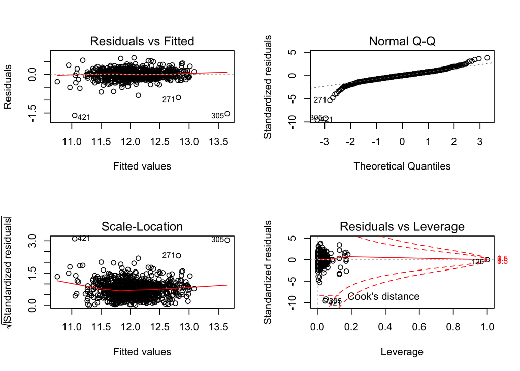

```r
par(mfrow = c(2,2))
plot(m_bic)
```

All the four plots indicates that the model is overally fine, except the abvious outlier points.

### 2.2.8 Section 2.4 Initial Model RMSE

You can calculate it directly based on the model output. Be specific about the units of your RMSE (depending on whether you transformed your response variable). The value you report will be more meaningful if it is in the original units (dollars).

```r
predictions = exp(predict(m_bic, ames_train_valid))
sqrt(mean((predictions - ames_train_valid$price)^2, na.rm = TRUE))
```

```
## [1] 38245.11
```

### 2.2.9 Section 2.5 Overfitting

The process of building a model generally involves starting with an initial model (as you have done above), identifying its shortcomings, and adapting the model accordingly. This process may be repeated several times until the model fits the data reasonably well. However, the model may do well on training data but perform poorly out-of-sample (meaning, on a dataset other than the original training data) because the model is overly-tuned to specifically fit the training data. This is called “overfitting.” To determine whether overfitting is occurring on a model, compare the performance of a model on both in-sample and out-of-sample data sets. To look at performance of your initial model on out-of-sample data, you will use the data set `ames_test`.

```r
load("ames_test.Rdata")
```

Use your model from above to generate predictions for the housing prices in the test data set. Are the predictions significantly more accurate (compared to the actual sales prices) for the training data than the test data? Why or why not? Briefly explain how you determined that (what steps or processes did you use)?

```r
prediction_test = exp(predict(m_bic, ames_test))
sqrt(mean((prediction_test - ames_test$price)^2, na.rm = TRUE))
```

```
## [1] 25905.65
```

To compare the performance of the model on training set and testing set, I calculated the RMSE for the testing set. This time, the RMSE is 25905.65, which is much lower than that for the training set. This fact indicates that our model has good generalization ability.

**Note to the learner:** If in real-life practice this out-of-sample analysis shows evidence that the training data fits your model a lot better than the test data, it is probably a good idea to go back and revise the model (usually by simplifying the model) to reduce this overfitting. For simplicity, we do not ask you to do this on the assignment, however.

## 2.3 Part 3 Development of a Final Model

Now that you have developed an initial model to use as a baseline, create a final model with *at most* 20 variables to predict housing prices in Ames, IA, selecting from the full array of variables in the dataset and using any of the tools that we introduced in this specialization.

Carefully document the process that you used to come up with your final model, so that you can answer the questions below.

### 2.3.1 Section 3.1 Final Model

Provide the summary table for your model.

For the final model, the variables I decided to include are: log(area), MS.Zoning, Neighborhood, Condition.1, Bldg.Type, Overall.Qual, Year.Built, Year.Remod.Add, Exter.Qual, Bsmt.Qual, Full.Bath, TotRms.AbvGrd, Garage.Type, area:Full.Bath. These variables all seem to have a strong relationship with the price.

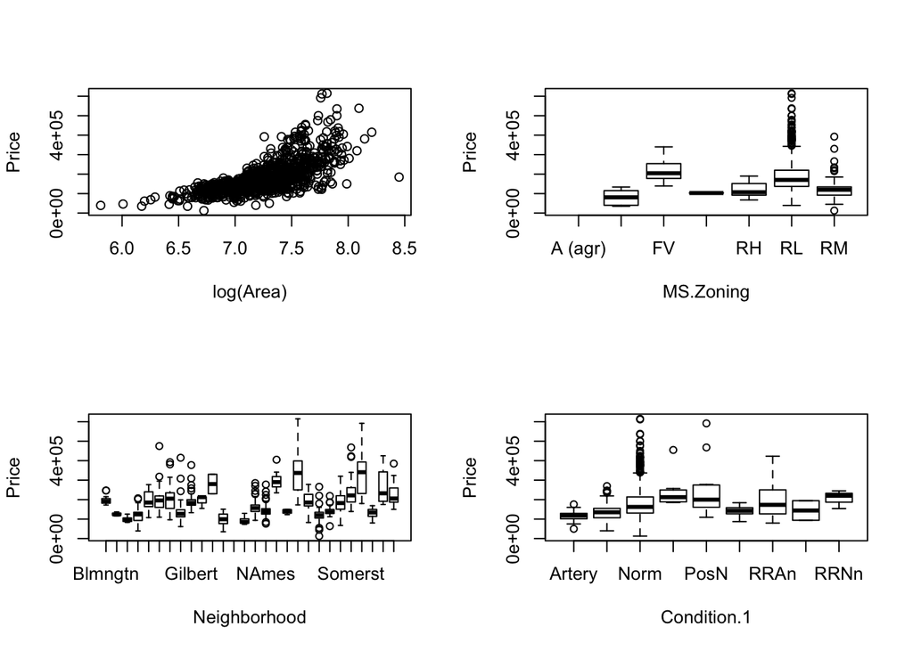

```r
par(mfrow = c(2,2))
plot(log(ames_train$area), ames_train$price,
     xlab = "log(Area)", ylab = "Price")
boxplot(price ~ MS.Zoning, data = ames_train,
        xlab = "MS.Zoning", ylab = "Price")
boxplot(price ~ Neighborhood, data = ames_train,
        xlab = "Neighborhood", ylab = "Price")
boxplot(price ~ Condition.1, data = ames_train,
        xlab = "Condition.1", ylab = "Price")
```

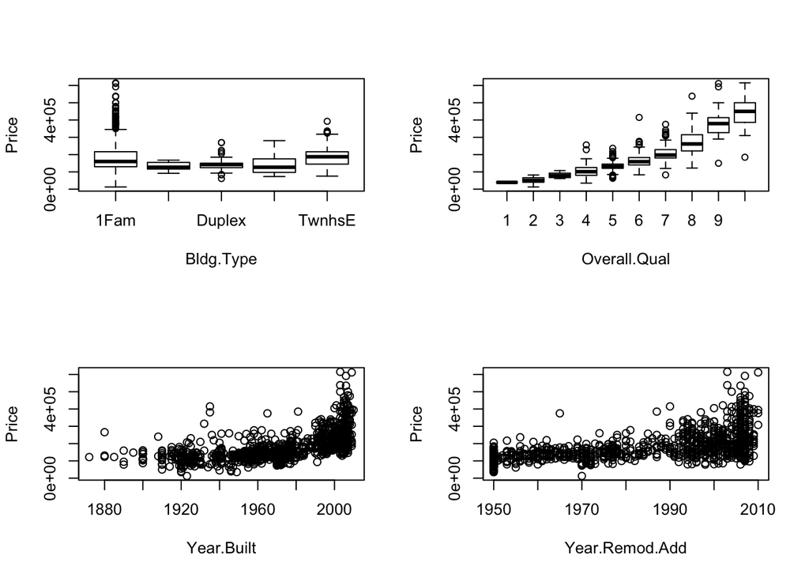

```r
boxplot(price ~ Bldg.Type, data = ames_train,
        xlab = "Bldg.Type", ylab = "Price")
boxplot(price ~ Overall.Qual, data = ames_train,
        xlab = "Overall.Qual", ylab = "Price")
plot(ames_train$Year.Built, ames_train$price,
     xlab = "Year.Built", ylab = "Price")
plot(ames_train$Year.Remod.Add, ames_train$price,
     xlab = "Year.Remod.Add", ylab = "Price")
```

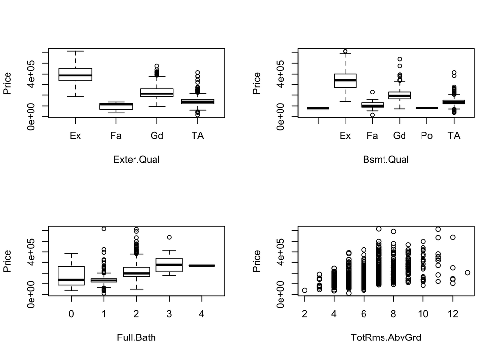

```r
boxplot(price ~ Exter.Qual, data = ames_train,
        xlab = "Exter.Qual", ylab = "Price")
boxplot(price ~ Bsmt.Qual, data = ames_train,
        xlab = "Bsmt.Qual", ylab = "Price")
boxplot(price ~ Full.Bath, data = ames_train,
        xlab = "Full.Bath", ylab = "Price")
plot(ames_train$TotRms.AbvGrd, ames_train$price,
     xlab = "TotRms.AbvGrd", ylab = "Price")
```

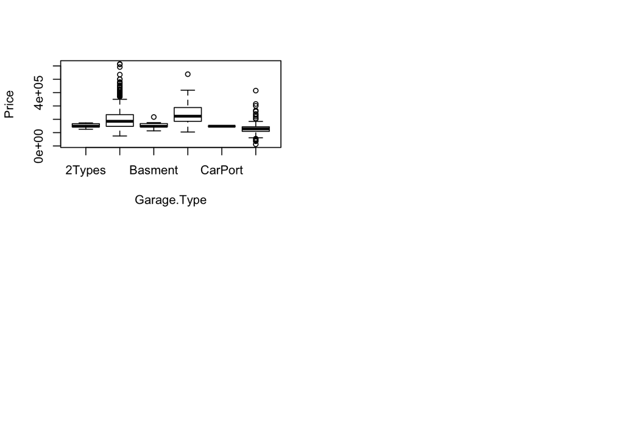

```r
boxplot(price ~ Garage.Type, data = ames_train,
        xlab = "Garage.Type", ylab = "Price")
```

Let’s fit the model using all these variables:

```r
ames_train_valid = na.omit(ames_train[,c("price", "area", "MS.Zoning", "Neighborhood", "Condition.1", "Bldg.Type", "Overall.Qual", "Year.Built", "Year.Remod.Add", "Exter.Qual", "Bsmt.Qual", "Full.Bath", "TotRms.AbvGrd", "Garage.Type")])
m_final = lm(log(price) ~ log(area) + MS.Zoning + Neighborhood + Condition.1 + Bldg.Type + Overall.Qual + Year.Built + Year.Remod.Add + Exter.Qual + Bsmt.Qual + Full.Bath + TotRms.AbvGrd + Garage.Type + area:Full.Bath, data = ames_train_valid)
summary(m_final)
```

```
##
## Call:
## lm(formula = log(price) ~ log(area) + MS.Zoning + Neighborhood +
##     Condition.1 + Bldg.Type + Overall.Qual + Year.Built + Year.Remod.Add +
##     Exter.Qual + Bsmt.Qual + Full.Bath + TotRms.AbvGrd + Garage.Type +
##     area:Full.Bath, data = ames_train_valid)
##
## Residuals:
##      Min       1Q   Median       3Q      Max
## -1.71609 -0.06725  0.00040  0.07406  0.57036
##
## Coefficients:
##                       Estimate Std. Error t value Pr(>|t|)
## (Intercept)         -2.404e+00  1.200e+00  -2.004 0.045361 *
## log(area)            4.384e-01  4.130e-02  10.615  < 2e-16 ***
## MS.ZoningFV          2.712e-01  8.562e-02   3.167 0.001592 **
## MS.ZoningI (all)     1.787e-01  1.641e-01   1.089 0.276569
## MS.ZoningRH          3.395e-01  1.008e-01   3.368 0.000792 ***
## MS.ZoningRL          3.959e-01  7.406e-02   5.345 1.16e-07 ***
## MS.ZoningRM          3.140e-01  6.883e-02   4.562 5.79e-06 ***
## NeighborhoodBlueste  1.602e-02  1.057e-01   0.152 0.879538
## NeighborhoodBrDale  -9.285e-02  8.082e-02  -1.149 0.250899
## NeighborhoodBrkSide  7.515e-02  6.855e-02   1.096 0.273245
## NeighborhoodClearCr  1.165e-01  6.743e-02   1.728 0.084375 .
## NeighborhoodCollgCr -3.311e-02  5.190e-02  -0.638 0.523676
## NeighborhoodCrawfor  1.722e-01  6.107e-02   2.819 0.004920 **
## NeighborhoodEdwards -6.059e-02  5.714e-02  -1.060 0.289241
## NeighborhoodGilbert -6.334e-02  5.447e-02  -1.163 0.245184
## NeighborhoodGreens   1.580e-01  9.097e-02   1.736 0.082836 .
## NeighborhoodGrnHill  5.886e-01  1.594e-01   3.693 0.000236 ***
## NeighborhoodIDOTRR  -5.502e-03  7.561e-02  -0.073 0.942010
## NeighborhoodMeadowV -1.184e-01  7.538e-02  -1.571 0.116657
## NeighborhoodMitchel  2.448e-02  5.644e-02   0.434 0.664621
## NeighborhoodNAmes    1.815e-02  5.556e-02   0.327 0.744075
## NeighborhoodNoRidge  7.416e-02  5.759e-02   1.288 0.198186
## NeighborhoodNPkVill  2.753e-02  9.367e-02   0.294 0.768878
## NeighborhoodNridgHt  1.282e-01  5.263e-02   2.436 0.015040 *
## NeighborhoodNWAmes  -1.398e-02  5.636e-02  -0.248 0.804115
## NeighborhoodOldTown  8.404e-03  6.978e-02   0.120 0.904162
## NeighborhoodSawyer   2.976e-02  5.753e-02   0.517 0.605105
```

[output cut: 28 more lines]

```
## Bsmt.QualTA          1.701e-01  1.541e-01   1.104 0.270045
## Full.Bath           -7.151e-02  2.572e-02  -2.780 0.005549 **
## TotRms.AbvGrd       -8.100e-03  6.334e-03  -1.279 0.201257
## Garage.TypeAttchd   -1.280e-03  5.045e-02  -0.025 0.979761
## Garage.TypeBasment  -1.057e-02  6.926e-02  -0.153 0.878735
## Garage.TypeBuiltIn  -9.203e-02  5.548e-02  -1.659 0.097525 .
## Garage.TypeCarPort  -3.351e-02  1.589e-01  -0.211 0.832988
## Garage.TypeDetchd   -2.261e-02  5.146e-02  -0.439 0.660468
## Full.Bath:area       2.636e-05  1.173e-05   2.248 0.024816 *
## ---
## Signif. codes:  0 '***' 0.001 '**' 0.01 '*' 0.05 '.' 0.1 ' ' 1
##
## Residual standard error: 0.1497 on 873 degrees of freedom
## Multiple R-squared:  0.8718, Adjusted R-squared:  0.8625
## F-statistic: 94.21 on 63 and 873 DF,  p-value: < 2.2e-16
```

The adjusted R-squared of the full model is 0.8625, and the RSE is 0.1497, both indicate a good fitting.

### 2.3.2 Section 3.2 Transformation

Did you decide to transform any variables? Why or why not? Explain in a few sentences.

I transformed the response variable **price**, and one of the predictor **area**. This is because the distribution of these two variables are both right-skewed.

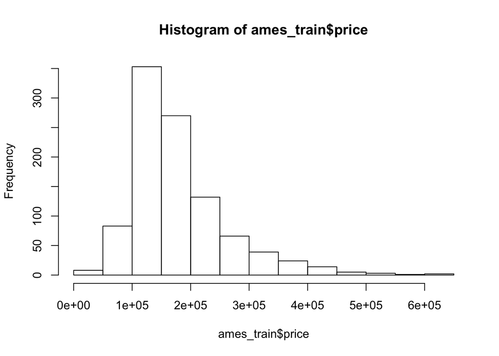

```r
hist(ames_train$price)
```

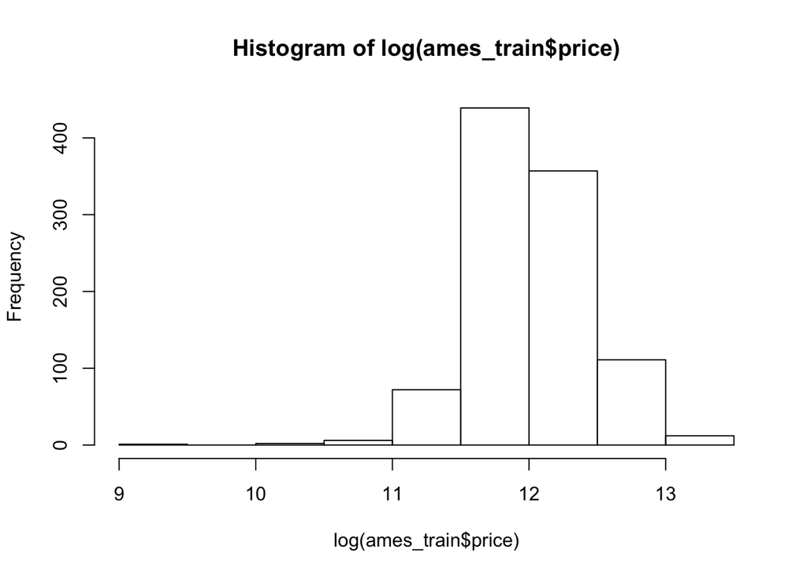

```r
hist(log(ames_train$price))
```

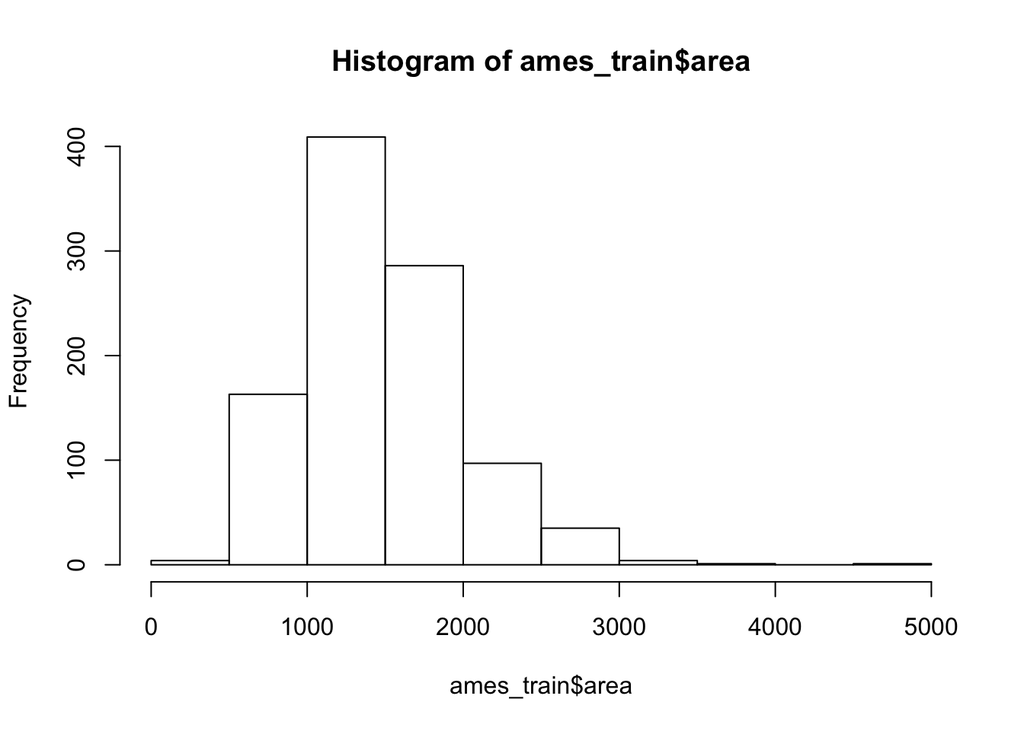

```r
hist(ames_train$area)
```

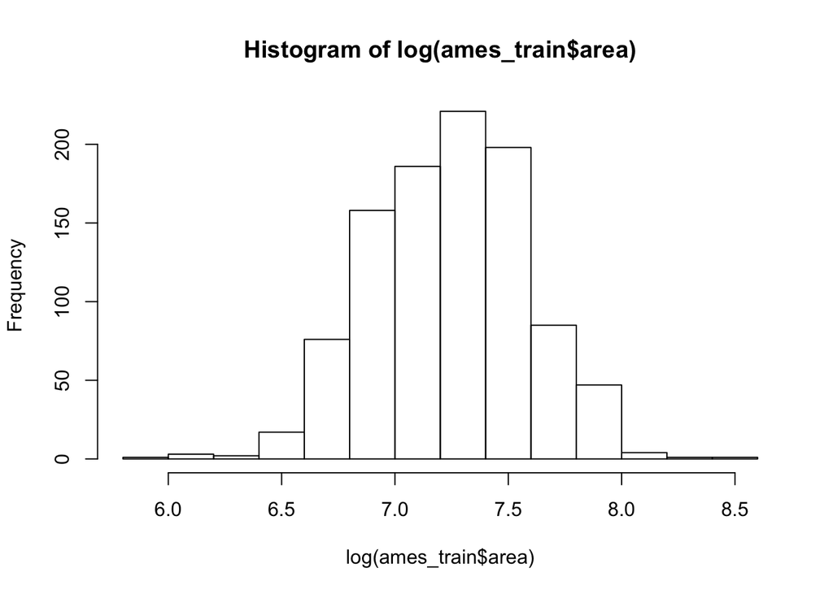

```r
hist(log(ames_train$area))
```

### 2.3.3 Section 3.3 Variable Interaction

Did you decide to include any variable interactions? Why or why not? Explain in a few sentences.

```r
summary(lm(price ~ area * Full.Bath, data = ames_train))
```

```
##
## Call:
## lm(formula = price ~ area * Full.Bath, data = ames_train)
##
## Residuals:
##     Min      1Q  Median      3Q     Max
## -297234  -28781   -2257   20262  331177
##
## Coefficients:
##                  Estimate Std. Error t value Pr(>|t|)
## (Intercept)    -33262.632  14787.184  -2.249  0.02470 *
## area              129.806     11.052  11.746  < 2e-16 ***
## Full.Bath       38222.280   9258.973   4.128 3.96e-05 ***
## area:Full.Bath    -14.713      5.628  -2.614  0.00908 **
## ---
## Signif. codes:  0 '***' 0.001 '**' 0.01 '*' 0.05 '.' 0.1 ' ' 1
##
## Residual standard error: 56920 on 996 degrees of freedom
## Multiple R-squared:  0.5185, Adjusted R-squared:  0.5171
## F-statistic: 357.5 on 3 and 996 DF,  p-value: < 2.2e-16
```

### 2.3.4 Section 3.4 Variable Selection

What method did you use to select the variables you included? Why did you select the method you used? Explain in a few sentences.

### 2.3.5 AIC Model Selection Method

Firstly, let’s use the AIC(Aikake information criterion) stepwise selection procedure. This is a typical frequentist model selection method. This procedure is a backward method, which starts from the full model and tries to remove one variable at a time, aiming to minimize AIC.

```r
stepAIC(m_final)
```

```
## Start:  AIC=-3497.43
## log(price) ~ log(area) + MS.Zoning + Neighborhood + Condition.1 +
##     Bldg.Type + Overall.Qual + Year.Built + Year.Remod.Add +
##     Exter.Qual + Bsmt.Qual + Full.Bath + TotRms.AbvGrd + Garage.Type +
##     area:Full.Bath
##
##                  Df Sum of Sq    RSS     AIC
## - TotRms.AbvGrd   1    0.0366 19.597 -3497.7
## <none>                        19.560 -3497.4
## - Full.Bath:area  1    0.1132 19.673 -3494.0
## - Condition.1     8    0.4407 20.001 -3492.6
## - Exter.Qual      3    0.2532 19.813 -3491.4
## - Garage.Type     5    0.3463 19.906 -3491.0
## - Bsmt.Qual       5    0.4842 20.044 -3484.5
## - Bldg.Type       4    0.7263 20.287 -3471.3
## - MS.Zoning       5    0.8402 20.400 -3468.0
## - Year.Built      1    0.7380 20.298 -3464.7
## - Year.Remod.Add  1    0.9509 20.511 -3454.9
## - Neighborhood   26    3.2123 22.772 -3407.0
## - Overall.Qual    1    2.1747 21.735 -3400.6
## - log(area)       1    2.5248 22.085 -3385.7
##
## Step:  AIC=-3497.68
## log(price) ~ log(area) + MS.Zoning + Neighborhood + Condition.1 +
##     Bldg.Type + Overall.Qual + Year.Built + Year.Remod.Add +
##     Exter.Qual + Bsmt.Qual + Full.Bath + Garage.Type + Full.Bath:area
##
##                  Df Sum of Sq    RSS     AIC
## <none>                        19.597 -3497.7
## - Full.Bath:area  1    0.1010 19.698 -3494.9
## - Condition.1     8    0.4350 20.032 -3493.1
## - Exter.Qual      3    0.2432 19.840 -3492.1
## - Garage.Type     5    0.3663 19.963 -3490.3
## - Bsmt.Qual       5    0.5063 20.103 -3483.8
## - Bldg.Type       4    0.6908 20.288 -3473.2
## - MS.Zoning       5    0.8439 20.441 -3468.2
## - Year.Built      1    0.7488 20.346 -3464.5
## - Year.Remod.Add  1    0.9486 20.545 -3455.4
## - Neighborhood   26    3.2095 22.806 -3407.6
## - Overall.Qual    1    2.1814 21.778 -3400.8
## - log(area)       1    2.9056 22.502 -3370.1
```

```
##
## Call:
## lm(formula = log(price) ~ log(area) + MS.Zoning + Neighborhood +
##     Condition.1 + Bldg.Type + Overall.Qual + Year.Built + Year.Remod.Add +
##     Exter.Qual + Bsmt.Qual + Full.Bath + Garage.Type + Full.Bath:area,
##     data = ames_train_valid)
##
## Coefficients:
##         (Intercept)            log(area)          MS.ZoningFV
##          -2.312e+00            4.132e-01            2.777e-01
##    MS.ZoningI (all)          MS.ZoningRH          MS.ZoningRL
##           1.855e-01            3.476e-01            4.000e-01
##         MS.ZoningRM  NeighborhoodBlueste   NeighborhoodBrDale
##           3.181e-01            1.714e-02           -9.260e-02
## NeighborhoodBrkSide  NeighborhoodClearCr  NeighborhoodCollgCr
##           8.329e-02            1.229e-01           -2.679e-02
## NeighborhoodCrawfor  NeighborhoodEdwards  NeighborhoodGilbert
##           1.792e-01           -5.202e-02           -5.843e-02
##  NeighborhoodGreens  NeighborhoodGrnHill   NeighborhoodIDOTRR
##           1.697e-01            5.979e-01            4.377e-03
## NeighborhoodMeadowV  NeighborhoodMitchel    NeighborhoodNAmes
##          -1.163e-01            3.109e-02            2.550e-02
## NeighborhoodNoRidge  NeighborhoodNPkVill  NeighborhoodNridgHt
##           8.073e-02            3.227e-02            1.309e-01
##  NeighborhoodNWAmes  NeighborhoodOldTown   NeighborhoodSawyer
##          -1.072e-02            1.569e-02            3.609e-02
## NeighborhoodSawyerW  NeighborhoodSomerst  NeighborhoodStoneBr
##          -7.543e-02            1.202e-01            1.729e-01
##   NeighborhoodSWISU   NeighborhoodTimber  NeighborhoodVeenker
##          -5.673e-04            5.632e-02            1.062e-01
##    Condition.1Feedr      Condition.1Norm      Condition.1PosA
##           1.497e-02            8.992e-02            1.511e-01
##     Condition.1PosN      Condition.1RRAe      Condition.1RRAn
##           4.652e-02            3.519e-02            4.326e-02
##     Condition.1RRNe      Condition.1RRNn      Bldg.Type2fmCon
##           3.726e-02           -3.791e-02            4.647e-02
##     Bldg.TypeDuplex       Bldg.TypeTwnhs      Bldg.TypeTwnhsE
##          -5.788e-02           -1.783e-01           -9.162e-02
##        Overall.Qual           Year.Built       Year.Remod.Add
##           7.253e-02            2.824e-03            2.431e-03
##        Exter.QualFa         Exter.QualGd         Exter.QualTA
##          -2.172e-01           -7.643e-02           -9.319e-02
##         Bsmt.QualEx          Bsmt.QualFa          Bsmt.QualGd
##           2.725e-01            8.117e-02            1.832e-01
##         Bsmt.QualPo          Bsmt.QualTA            Full.Bath
##           3.319e-01            1.636e-01           -6.956e-02
##   Garage.TypeAttchd   Garage.TypeBasment   Garage.TypeBuiltIn
##           4.364e-04           -9.773e-03           -9.258e-02
##  Garage.TypeCarPort    Garage.TypeDetchd       Full.Bath:area
##          -2.781e-02           -2.167e-02            2.475e-05
```

```r
m_aic_final = lm(log(price) ~ log(area) + MS.Zoning + Neighborhood + Condition.1 + Bldg.Type + Overall.Qual + Year.Built +  Year.Remod.Add + Exter.Qual + Bsmt.Qual + Full.Bath + Garage.Type +  Full.Bath:area, data = ames_train_valid)
summary(m_aic_final)
```

```
##
## Call:
## lm(formula = log(price) ~ log(area) + MS.Zoning + Neighborhood +
##     Condition.1 + Bldg.Type + Overall.Qual + Year.Built + Year.Remod.Add +
##     Exter.Qual + Bsmt.Qual + Full.Bath + Garage.Type + Full.Bath:area,
##     data = ames_train_valid)
##
## Residuals:
##      Min       1Q   Median       3Q      Max
## -1.71581 -0.06767  0.00147  0.07573  0.56826
##
## Coefficients:
##                       Estimate Std. Error t value Pr(>|t|)
## (Intercept)         -2.312e+00  1.198e+00  -1.930 0.053958 .
## log(area)            4.132e-01  3.630e-02  11.384  < 2e-16 ***
## MS.ZoningFV          2.777e-01  8.550e-02   3.248 0.001205 **
## MS.ZoningI (all)     1.855e-01  1.641e-01   1.131 0.258459
## MS.ZoningRH          3.476e-01  1.007e-01   3.454 0.000579 ***
## MS.ZoningRL          4.000e-01  7.402e-02   5.404 8.43e-08 ***
## MS.ZoningRM          3.181e-01  6.878e-02   4.624 4.33e-06 ***
## NeighborhoodBlueste  1.714e-02  1.057e-01   0.162 0.871226
## NeighborhoodBrDale  -9.260e-02  8.085e-02  -1.145 0.252347
## NeighborhoodBrkSide  8.329e-02  6.828e-02   1.220 0.222842
## NeighborhoodClearCr  1.229e-01  6.727e-02   1.827 0.068106 .
## NeighborhoodCollgCr -2.679e-02  5.169e-02  -0.518 0.604373
## NeighborhoodCrawfor  1.792e-01  6.084e-02   2.945 0.003314 **
## NeighborhoodEdwards -5.202e-02  5.677e-02  -0.916 0.359752
## NeighborhoodGilbert -5.843e-02  5.435e-02  -1.075 0.282686
## NeighborhoodGreens   1.697e-01  9.054e-02   1.874 0.061284 .
## NeighborhoodGrnHill  5.979e-01  1.593e-01   3.754 0.000185 ***
## NeighborhoodIDOTRR   4.377e-03  7.524e-02   0.058 0.953631
## NeighborhoodMeadowV -1.163e-01  7.539e-02  -1.543 0.123304
## NeighborhoodMitchel  3.109e-02  5.623e-02   0.553 0.580440
## NeighborhoodNAmes    2.550e-02  5.529e-02   0.461 0.644784
## NeighborhoodNoRidge  8.073e-02  5.739e-02   1.407 0.159840
## NeighborhoodNPkVill  3.227e-02  9.363e-02   0.345 0.730436
## NeighborhoodNridgHt  1.309e-01  5.260e-02   2.489 0.012998 *
## NeighborhoodNWAmes  -1.072e-02  5.633e-02  -0.190 0.849152
## NeighborhoodOldTown  1.569e-02  6.957e-02   0.226 0.821592
## NeighborhoodSawyer   3.609e-02  5.734e-02   0.629 0.529241
```

[output cut: 27 more lines]

```
## Bsmt.QualPo          3.319e-01  2.242e-01   1.480 0.139143
## Bsmt.QualTA          1.636e-01  1.541e-01   1.061 0.288778
## Full.Bath           -6.956e-02  2.568e-02  -2.708 0.006897 **
## Garage.TypeAttchd    4.364e-04  5.045e-02   0.009 0.993100
## Garage.TypeBasment  -9.773e-03  6.929e-02  -0.141 0.887864
## Garage.TypeBuiltIn  -9.258e-02  5.550e-02  -1.668 0.095658 .
## Garage.TypeCarPort  -2.781e-02  1.589e-01  -0.175 0.861068
## Garage.TypeDetchd   -2.167e-02  5.147e-02  -0.421 0.673769
## Full.Bath:area       2.475e-05  1.166e-05   2.122 0.034087 *
## ---
## Signif. codes:  0 '***' 0.001 '**' 0.01 '*' 0.05 '.' 0.1 ' ' 1
##
## Residual standard error: 0.1497 on 874 degrees of freedom
## Multiple R-squared:  0.8715, Adjusted R-squared:  0.8624
## F-statistic: 95.64 on 62 and 874 DF,  p-value: < 2.2e-16
```

From the above result, we can see only the variable **TotRms.AbvGrd** is removed from the model. And the adjusted R-squared of AIC model is 0.8624, almost the same as the original model.

### 2.3.6 BIC Model Selection Method

Next, let’s use the BIC(Bayesian information criterion) stepwise selection procedure. This is similar to AIC method, but instead trying to minimize BIC.

```r
stepAIC(m_final, k = log(nrow(ames_train_valid)))
```

```
## Start:  AIC=-3187.5
## log(price) ~ log(area) + MS.Zoning + Neighborhood + Condition.1 +
##     Bldg.Type + Overall.Qual + Year.Built + Year.Remod.Add +
##     Exter.Qual + Bsmt.Qual + Full.Bath + TotRms.AbvGrd + Garage.Type +
##     area:Full.Bath
##
##                  Df Sum of Sq    RSS     AIC
## - Neighborhood   26    3.2123 22.772 -3222.9
## - Condition.1     8    0.4407 20.001 -3221.4
## - Garage.Type     5    0.3463 19.906 -3205.3
## - Bsmt.Qual       5    0.4842 20.044 -3198.8
## - Exter.Qual      3    0.2532 19.813 -3196.0
## - TotRms.AbvGrd   1    0.0366 19.597 -3192.6
## - Full.Bath:area  1    0.1132 19.673 -3188.9
## <none>                        19.560 -3187.5
## - MS.Zoning       5    0.8402 20.400 -3182.3
## - Bldg.Type       4    0.7263 20.287 -3180.7
## - Year.Built      1    0.7380 20.298 -3159.6
## - Year.Remod.Add  1    0.9509 20.511 -3149.9
## - Overall.Qual    1    2.1747 21.735 -3095.6
## - log(area)       1    2.5248 22.085 -3080.6
##
## Step:  AIC=-3222.93
## log(price) ~ log(area) + MS.Zoning + Condition.1 + Bldg.Type +
##     Overall.Qual + Year.Built + Year.Remod.Add + Exter.Qual +
##     Bsmt.Qual + Full.Bath + TotRms.AbvGrd + Garage.Type + Full.Bath:area
##
##                  Df Sum of Sq    RSS     AIC
## - Condition.1     8    0.4500 23.222 -3259.3
## - Garage.Type     5    0.3427 23.115 -3243.1
## - TotRms.AbvGrd   1    0.0339 22.806 -3228.4
## - Full.Bath:area  1    0.1448 22.917 -3223.8
## <none>                        22.772 -3222.9
## - Bsmt.Qual       5    0.8878 23.660 -3221.3
## - Exter.Qual      3    0.5634 23.336 -3220.6
## - Bldg.Type       4    0.9325 23.705 -3212.7
## - Year.Built      1    0.5476 23.320 -3207.5
## - Year.Remod.Add  1    0.8606 23.633 -3195.0
## - MS.Zoning       5    1.8578 24.630 -3183.7
## - log(area)       1    2.6939 25.466 -3125.0
```

[output cut: 57 more lines]

```
## Step:  AIC=-3288.85
## log(price) ~ log(area) + MS.Zoning + Bldg.Type + Overall.Qual +
##     Year.Built + Year.Remod.Add + Exter.Qual + Bsmt.Qual + Full.Bath
##
##                  Df Sum of Sq    RSS     AIC
## <none>                        23.683 -3288.8
## - Full.Bath       1    0.2572 23.940 -3285.6
## - Exter.Qual      3    0.6452 24.328 -3284.2
## - Bsmt.Qual       5    1.0310 24.714 -3283.1
## - Bldg.Type       4    0.8955 24.578 -3281.4
## - Year.Built      1    0.6824 24.365 -3269.1
## - Year.Remod.Add  1    0.8901 24.573 -3261.1
## - MS.Zoning       5    2.1323 25.815 -3242.3
## - Overall.Qual    1    3.7960 27.479 -3156.4
## - log(area)       1    8.6798 32.363 -3003.1
```

```
##
## Call:
## lm(formula = log(price) ~ log(area) + MS.Zoning + Bldg.Type +
##     Overall.Qual + Year.Built + Year.Remod.Add + Exter.Qual +
##     Bsmt.Qual + Full.Bath, data = ames_train_valid)
##
## Coefficients:
##      (Intercept)         log(area)       MS.ZoningFV  MS.ZoningI (all)
##        -0.395453          0.476690          0.402095          0.149799
##      MS.ZoningRH       MS.ZoningRL       MS.ZoningRM   Bldg.Type2fmCon
##         0.304011          0.437257          0.306615          0.052561
##  Bldg.TypeDuplex    Bldg.TypeTwnhs   Bldg.TypeTwnhsE      Overall.Qual
##        -0.052395         -0.166385         -0.042123          0.088188
##       Year.Built    Year.Remod.Add      Exter.QualFa      Exter.QualGd
##         0.001858          0.002241         -0.309791         -0.126125
##     Exter.QualTA       Bsmt.QualEx       Bsmt.QualFa       Bsmt.QualGd
##        -0.165126          0.275629          0.024676          0.141184
##      Bsmt.QualPo       Bsmt.QualTA         Full.Bath
##         0.210060          0.125211         -0.047815
```

```r
m_bic_final = lm(log(price) ~ log(area) + MS.Zoning + Bldg.Type +
    Overall.Qual + Year.Built + Year.Remod.Add + Exter.Qual +
    Bsmt.Qual + Full.Bath, data = ames_train_valid)
summary(m_bic_final)
```

```
##
## Call:
## lm(formula = log(price) ~ log(area) + MS.Zoning + Bldg.Type +
##     Overall.Qual + Year.Built + Year.Remod.Add + Exter.Qual +
##     Bsmt.Qual + Full.Bath, data = ames_train_valid)
##
## Residuals:
##      Min       1Q   Median       3Q      Max
## -1.63593 -0.08311  0.00485  0.08263  0.60872
##
## Coefficients:
##                    Estimate Std. Error t value Pr(>|t|)
## (Intercept)      -0.3954526  0.9561381  -0.414  0.67927
## log(area)         0.4766898  0.0260449  18.303  < 2e-16 ***
## MS.ZoningFV       0.4020947  0.0727098   5.530 4.18e-08 ***
## MS.ZoningI (all)  0.1497987  0.1753686   0.854  0.39322
## MS.ZoningRH       0.3040113  0.0985774   3.084  0.00210 **
## MS.ZoningRL       0.4372574  0.0686227   6.372 2.96e-10 ***
## MS.ZoningRM       0.3066152  0.0685638   4.472 8.72e-06 ***
## Bldg.Type2fmCon   0.0525606  0.0415315   1.266  0.20599
## Bldg.TypeDuplex  -0.0523946  0.0377595  -1.388  0.16560
## Bldg.TypeTwnhs   -0.1663847  0.0302578  -5.499 4.96e-08 ***
## Bldg.TypeTwnhsE  -0.0421232  0.0212173  -1.985  0.04741 *
## Overall.Qual      0.0881877  0.0072860  12.104  < 2e-16 ***
## Year.Built        0.0018579  0.0003620   5.132 3.51e-07 ***
## Year.Remod.Add    0.0022411  0.0003824   5.861 6.41e-09 ***
## Exter.QualFa     -0.3097912  0.0715356  -4.331 1.65e-05 ***
## Exter.QualGd     -0.1261250  0.0328230  -3.843  0.00013 ***
## Exter.QualTA     -0.1651258  0.0373969  -4.415 1.13e-05 ***
## Bsmt.QualEx       0.2756294  0.1650107   1.670  0.09519 .
## Bsmt.QualFa       0.0246760  0.1652379   0.149  0.88132
## Bsmt.QualGd       0.1411838  0.1630755   0.866  0.38685
## Bsmt.QualPo       0.2100605  0.2388270   0.880  0.37933
## Bsmt.QualTA       0.1252108  0.1621915   0.772  0.44032
## Full.Bath        -0.0478147  0.0151752  -3.151  0.00168 **
## ---
## Signif. codes:  0 '***' 0.001 '**' 0.01 '*' 0.05 '.' 0.1 ' ' 1
##
## Residual standard error: 0.161 on 914 degrees of freedom
## Multiple R-squared:  0.8448, Adjusted R-squared:  0.841
## F-statistic: 226.1 on 22 and 914 DF,  p-value: < 2.2e-16
```

From the above result, we can see BIC method removed **Neighborhood**, **Condition.1**, **Garage.Type**, **Full.Bath:area**, and **TotRms.AbvGrd** from the initial model. And the adjusted R-squared is now 0.841.

### 2.3.7 BAS Model Selection Method

Next, let’s use BAS model selection method, which is a Bayesian statistical method.

```r
bas_ml = bas.lm(log(price) ~ log(area) + MS.Zoning + Neighborhood + Condition.1 + Bldg.Type + Overall.Qual + Year.Built + Year.Remod.Add + Exter.Qual + Bsmt.Qual + Full.Bath + TotRms.AbvGrd + Garage.Type + area:Full.Bath, data = ames_train_valid)
round(summary(bas_ml), 3)
```

```
##      Intercept log(area) MS.ZoningFV MS.ZoningI (all) MS.ZoningRH
## [1,]         1         1           1                0           1
## [2,]         1         1           1                0           1
## [3,]         1         1           1                0           1
## [4,]         1         1           1                0           1
## [5,]         1         1           1                0           1
##      MS.ZoningRL MS.ZoningRM NeighborhoodBlueste NeighborhoodBrDale
## [1,]           1           1                   0                  0
## [2,]           1           1                   0                  0
## [3,]           1           1                   0                  0
## [4,]           1           1                   0                  0
## [5,]           1           1                   0                  0
##      NeighborhoodBrkSide NeighborhoodClearCr NeighborhoodCollgCr
## [1,]                   0                   0                   1
## [2,]                   1                   0                   1
```

[output cut: 93 more lines]

We can see that the model with highest posterior probability include the ** log(area)**,** MS.ZoningFV**,** MS.ZoningRH**,** MS.ZoningRL**,** MS.ZoningRM**,** NeighborhoodCollgCr**,** NeighborhoodCrawfor**,** NeighborhoodEdwards**,** NeighborhoodGilbert**,** NeighborhoodGrnHill**,** NeighborhoodNridgHt**,** NeighborhoodSawyerW**,** NeighborhoodStoneBr**,** Condition.1Norm**,** Bldg.TypeTwnhs**,** Bldg.TypeTwnhsE**,** Overall.Qual**,** Year.Built**,** Year.Remod.Add**,** Bsmt.QualEx**, and** Garage.TypeBuiltIn**. The corresponding R-squared is 0.859.

Again, I will use the BIC method selected model in the following parts.

### 2.3.8 Section 3.5 Model Testing

How did testing the model on out-of-sample data affect whether or how you changed your model? Explain in a few sentences.

Now, let’s calculate the RMSE for both training and testing sets.

```r
predictions = exp(predict(m_bic_final, ames_train_valid))
sqrt(mean((predictions - ames_train_valid$price)^2, na.rm = TRUE))
```

```
## [1] 33674.59
```

```r
prediction_test = exp(predict(m_bic_final, ames_test))
sqrt(mean((prediction_test - ames_test$price)^2, na.rm = TRUE))
```

```
## [1] 27732.96
```

This time, it appears that the testing set again has a lower RMSE, indicating good overall fitting quality. Therefore, I would not change my final model.

## 2.4 Part 4 Final Model Assessment

### 2.4.1 Section 4.1 Final Model Residual

For your final model, create and briefly interpret an informative plot of the residuals.

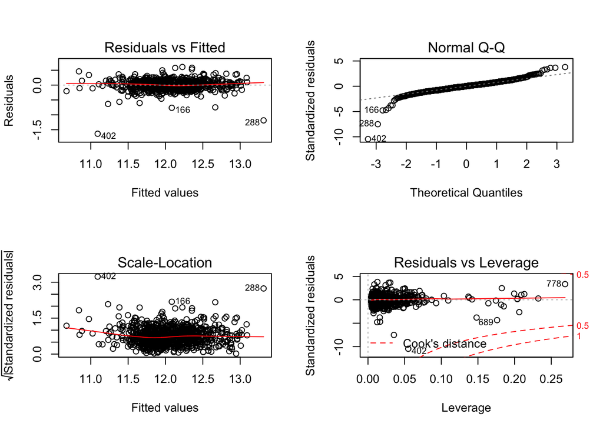

```r
par(mfrow = c(2,2))
plot(m_bic_final)
```

All the four plots indicates that the model is overally fine, except the abvious outlier points.

### 2.4.2 Section 4.2 Final Model RMSE

For your final model, calculate and briefly comment on the RMSE.

```r
predictions = exp(predict(m_bic_final, ames_train_valid))
sqrt(mean((predictions - ames_train_valid$price)^2, na.rm = TRUE))
```

```
## [1] 33674.59
```

As calculated above, the RMSE on training set is 33674.59 dollars for this final model. Again, compared to the median of price(159500), this RMSE is of the reasonable level.

### 2.4.3 Section 4.3 Final Model Evaluation

What are some strengths and weaknesses of your model?

### 2.4.4 Strengths:

Good performance on the training set and testing set.  
No overfitting detected.

### 2.4.5 Weaknesses:

Some of the variables are insiginificant, but are included by the BIC model selection method.  
Many categorical variables are included, making the model complex and kind of hard to interpret.

### 2.4.6 Section 4.4 Final Model Validation

Testing your final model on a separate, validation data set is a great way to determine how your model will perform in real-life practice.

You will use the “ames_validation” dataset to do some additional assessment of your final model. Discuss your findings, be sure to mention: * What is the RMSE of your final model when applied to the validation data?  
* How does this value compare to that of the training data and/or testing data? * What percentage of the 95% predictive confidence (or credible) intervals contain the true price of the house in the validation data set?  
* From this result, does your final model properly reflect uncertainty?

```r
load("ames_validation.Rdata")
ames_validation = filter(ames_validation, MS.Zoning != "A (agr)")
prediction_validation = exp(predict(m_bic_final, ames_validation))
sqrt(mean((prediction_validation - ames_validation$price)^2, na.rm = TRUE))
```

```
## [1] 26960.89
```

The RMSE on the validation set is 26960.89, even lower than that on the testing set.

```r
prediction_inv = data.frame(predict(m_bic_final, ames_validation, level = 0.95, interval = "prediction"))
# number of predictive confidence intervals that contains the true price
true_count = nrow(ames_validation[log(ames_validation$price) >= prediction_inv$lwr | log(ames_validation$price) <= prediction_inv$upr,]) - sum(is.na(prediction_inv))
# percentage
true_count / nrow(ames_validation)
```

```
## [1] 0.9055118
```

Over 90% of the 95% predictive confidence intervals contain the true price of the house in the validation data set.

From this result, I think my final model properly reflects uncertainty.

## 2.5 Part 5 Conclusion

Provide a brief summary of your results, and a brief discussion of what you have learned about the data and your model.

From the data and my model, I learned that the price of a house could be predicted given its area, zoning category, building type, overall quality, year built, year remodeled, exterior quality, basement quality and the number of full bathrooms.